# NOAA DATASET DISASTER<sub>HEALTH</sub>ECONOMY ANALYSIS

Satyam Kumar

25/08/2020

## SYNOPSIS

Storms and other severe weather events can cause both public health and economic problems for communities and municipalities. Many severe events can result in fatalities, injuries, and property damage, and preventing such outcomes to the extent possible is a key concern.

This project involves exploring the U.S. National Oceanic and Atmospheric Administration’s (NOAA) storm database. This database tracks characteristics of major storms and weather events in the United States, including when and where they occur, as well as estimates of any fatalities, injuries, and property damage.

Hence here we will explore about two things, that is the trend between the disaster and its effects on human health and economic damage.

```r
library(ggplot2)
library(dplyr)
library(plyr)
library(tidyr)
```

```r
storm_data <- read.csv(bzfile("repdata_data_StormData.csv.bz2"),header = TRUE)
```

```r
str(storm_data)
```

```
## 'data.frame':    902297 obs. of  37 variables:
##  $ STATE__   : num  1 1 1 1 1 1 1 1 1 1 ...
##  $ BGN_DATE  : chr  "4/18/1950 0:00:00" "4/18/1950 0:00:00" "2/20/1951 0:00:00" "6/8/1951 0:00:00" ...
##  $ BGN_TIME  : chr  "0130" "0145" "1600" "0900" ...
##  $ TIME_ZONE : chr  "CST" "CST" "CST" "CST" ...
##  $ COUNTY    : num  97 3 57 89 43 77 9 123 125 57 ...
##  $ COUNTYNAME: chr  "MOBILE" "BALDWIN" "FAYETTE" "MADISON" ...
##  $ STATE     : chr  "AL" "AL" "AL" "AL" ...
##  $ EVTYPE    : chr  "TORNADO" "TORNADO" "TORNADO" "TORNADO" ...
##  $ BGN_RANGE : num  0 0 0 0 0 0 0 0 0 0 ...
##  $ BGN_AZI   : chr  "" "" "" "" ...
##  $ BGN_LOCATI: chr  "" "" "" "" ...
##  $ END_DATE  : chr  "" "" "" "" ...
##  $ END_TIME  : chr  "" "" "" "" ...
##  $ COUNTY_END: num  0 0 0 0 0 0 0 0 0 0 ...
```

[output cut: 23 more lines]

## DATA PROCESSING

#FIRST I LOADED THE DATA INTO THE WORKSPACE

#EXTRACTED THE USEFUL COLUMN FORM IT AND MADE ASEPARATE DATASET OUT OF THAT

#CHANGED THE CATEGORICAL UNITS INTO QUANTITATIVE ONES

#AGGREGATED THE DATA BY EVENTS

#PLOTTED THE DATA FOR RESULTS

```r
extract <- storm_data[,c("EVTYPE", "FATALITIES", "INJURIES", "PROPDMG", "PROPDMGEXP", "CROPDMG", "CROPDMGEXP")]
head(extract)
```

```
##    EVTYPE FATALITIES INJURIES PROPDMG PROPDMGEXP CROPDMG CROPDMGEXP
## 1 TORNADO          0       15    25.0          K       0
## 2 TORNADO          0        0     2.5          K       0
## 3 TORNADO          0        2    25.0          K       0
## 4 TORNADO          0        2     2.5          K       0
## 5 TORNADO          0        2     2.5          K       0
## 6 TORNADO          0        6     2.5          K       0
```

```r
fatalities <- aggregate(FATALITIES~EVTYPE,extract,sum)
injuries <- aggregate(INJURIES~EVTYPE,extract,sum)
extract$PROPDMGEXP <- mapvalues(extract$PROPDMGEXP, from = c("K", "M","", "B", "m", "+", "0", "5", "6", "?", "4", "2", "3", "h", "7", "H", "-", "1", "8"), to = c(10^3, 10^6, 1, 10^9, 10^6, 0,1,10^5, 10^6, 0, 10^4, 10^2, 10^3, 10^2, 10^7, 10^2, 0, 10, 10^8))
extract$PROPDMGEXP <- as.numeric(as.character(extract$PROPDMGEXP))
extract$PROPDMGTOTAL <- (extract$PROPDMG * extract$PROPDMGEXP)/1000000000
unique(extract$CROPDMGEXP)
```

```
## [1] ""  "M" "K" "m" "B" "?" "0" "k" "2"
```

```r
extract$CROPDMGEXP <- mapvalues(extract$CROPDMGEXP, from = c("","M", "K", "m", "B", "?", "0", "k","2"), to = c(1,10^6, 10^3, 10^6, 10^9, 0, 1, 10^3, 10^2))
extract$CROPDMGEXP <- as.numeric(as.character(extract$CROPDMGEXP))
extract$CROPDMGTOTAL <- (extract$CROPDMG * extract$CROPDMGEXP)/1000000000
cropdmg <- aggregate(CROPDMGTOTAL~EVTYPE,extract,sum)
propdmg <- aggregate(PROPDMGTOTAL~EVTYPE,extract,sum)
head(fatalities)
```

```
##                  EVTYPE FATALITIES
## 1    HIGH SURF ADVISORY          0
## 2         COASTAL FLOOD          0
## 3           FLASH FLOOD          0
## 4             LIGHTNING          0
## 5             TSTM WIND          0
## 6       TSTM WIND (G45)          0
```

```r
head(injuries)
```

```
##                  EVTYPE INJURIES
## 1    HIGH SURF ADVISORY        0
## 2         COASTAL FLOOD        0
## 3           FLASH FLOOD        0
## 4             LIGHTNING        0
## 5             TSTM WIND        0
## 6       TSTM WIND (G45)        0
```

```r
head(cropdmg)
```

```
##                  EVTYPE CROPDMGTOTAL
## 1    HIGH SURF ADVISORY            0
## 2         COASTAL FLOOD            0
## 3           FLASH FLOOD            0
## 4             LIGHTNING            0
## 5             TSTM WIND            0
## 6       TSTM WIND (G45)            0
```

```r
head(propdmg)
```

```
##                  EVTYPE PROPDMGTOTAL
## 1    HIGH SURF ADVISORY      2.0e-04
## 2         COASTAL FLOOD      0.0e+00
## 3           FLASH FLOOD      5.0e-05
## 4             LIGHTNING      0.0e+00
## 5             TSTM WIND      8.1e-03
## 6       TSTM WIND (G45)      8.0e-06
```

```r
fatalities <- fatalities[order(-fatalities$FATALITIES),][1:10,]
injuries <- injuries[order(-injuries$INJURIES),][1:10,]
cropdmg <- cropdmg[order(-cropdmg$CROPDMGTOTAL),]
propdmg <- propdmg[order(-propdmg$PROPDMGTOTAL),]
econdmg <- inner_join(cropdmg,propdmg)[1:10,]
```

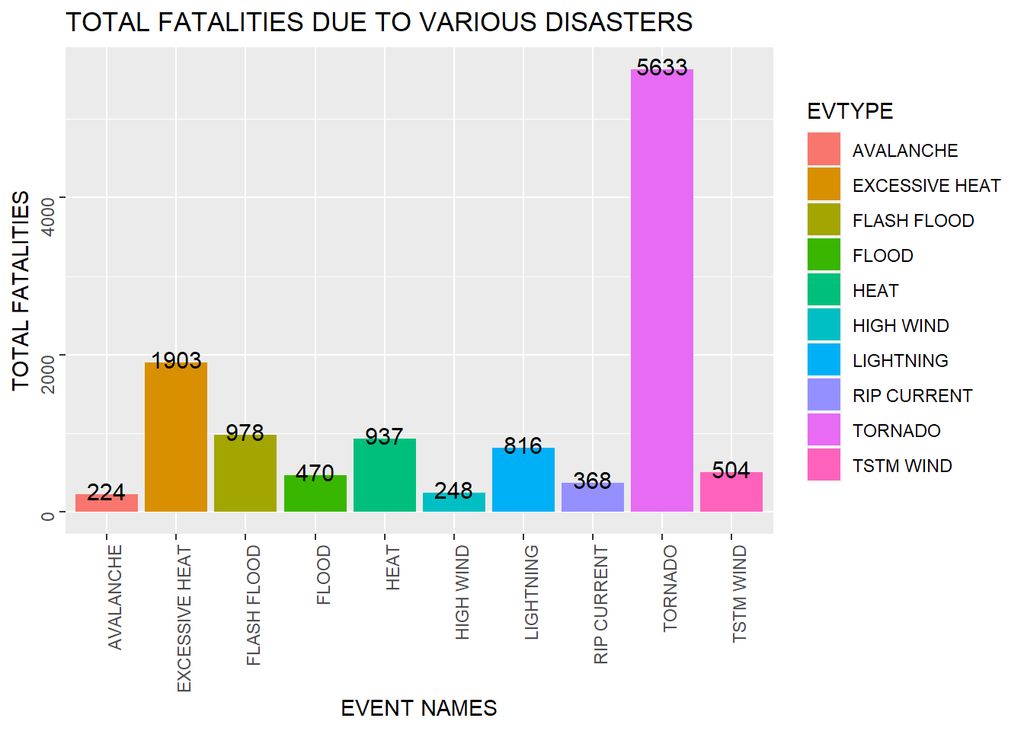

```r
ggplot(fatalities,aes(EVTYPE,FATALITIES,fill=EVTYPE))+geom_bar(stat = 'identity')+geom_text(aes(label=FATALITIES),vjust=0.3,size=4)+theme(axis.text=element_text(angle=90,hjust=1,vjust=0.5))+labs(x='EVENT NAMES',y='TOTAL FATALITIES',title = 'TOTAL FATALITIES DUE TO VARIOUS DISASTERS')
```

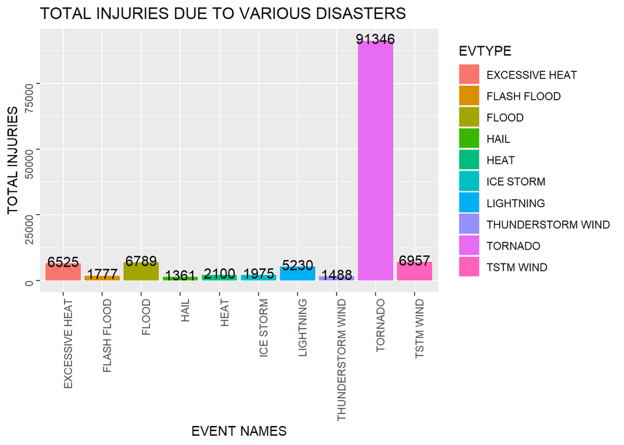

```r
ggplot(injuries,aes(EVTYPE,INJURIES,fill=EVTYPE))+geom_bar(stat = 'identity')+geom_text(aes(label=INJURIES),vjust=0.3,size=4)+theme(axis.text=element_text(angle=90,hjust=1,vjust=0.5))+labs(x='EVENT NAMES',y='TOTAL INJURIES',title = 'TOTAL INJURIES DUE TO VARIOUS DISASTERS')
```

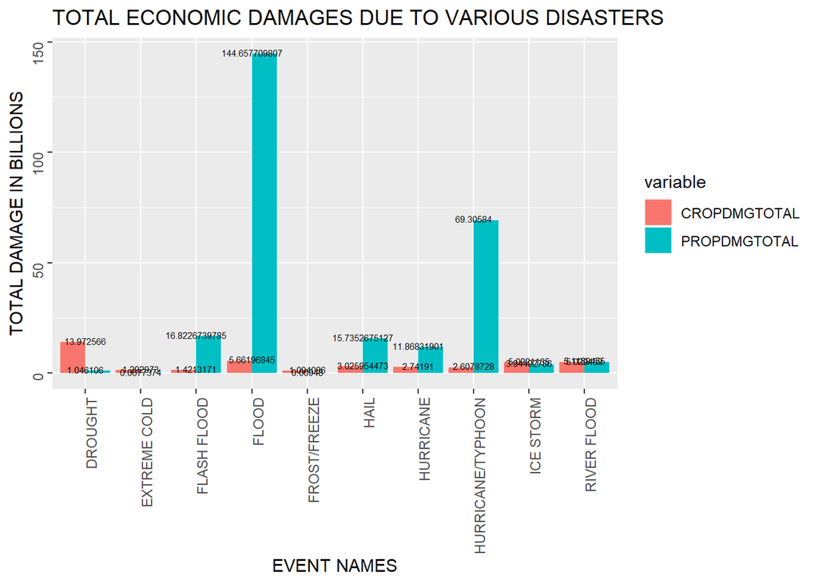

```r
econdmg.long <- gather(econdmg,variable,value,-EVTYPE)
ggplot(data = econdmg.long, aes(x = EVTYPE, y = value, fill = variable))+geom_col(position=position_dodge())+theme(axis.text=element_text(angle=90,hjust=1,vjust=0.5))+labs(x='EVENT NAMES',y='TOTAL DAMAGE IN BILLIONS',title = 'TOTAL ECONOMIC DAMAGES DUE TO VARIOUS DISASTERS')+geom_text(aes(label=value),vjust=0.3,size=2)
```

# RESULTS

THE MOST HARMFUL DISASTER FOR HUMAN HEALTH IS TORNADO

THE MOST HARMFUL DISASTER FOR ECONOMIC IMPACTS IS A FLOOD